# 01_triangle_3rd_angle_deg

## 01_triangle_3rd_angle_deg

#### Question

1. A triangle is drawn. Two of the interior angle measures are known to be 72.6° and 45.5°. Find the third interior angle measure in degrees.

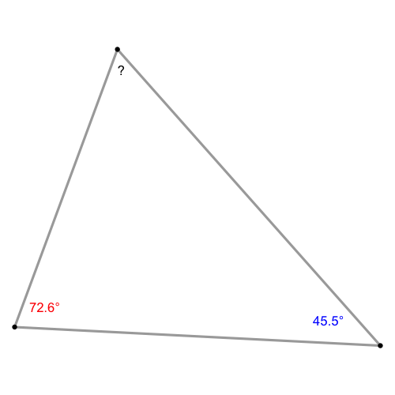

#### Question

2. A triangle is drawn. Two of the interior angle measures are known to be 102.9° and 45.9°. Find the third interior angle measure in degrees.

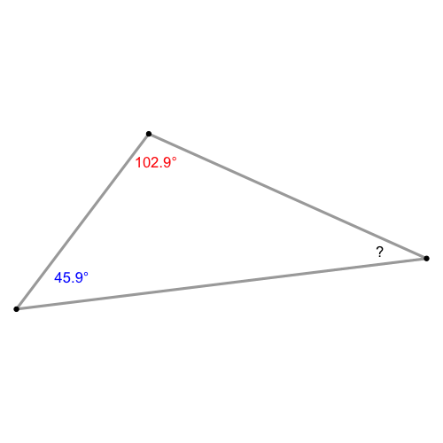

#### Question

3. A triangle is drawn. Two of the interior angle measures are known to be 86.6° and 35.8°. Find the third interior angle measure in degrees.

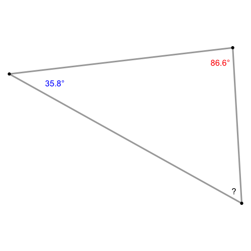

#### Question

4. A triangle is drawn. Two of the interior angle measures are known to be 58.9° and 53.7°. Find the third interior angle measure in degrees.

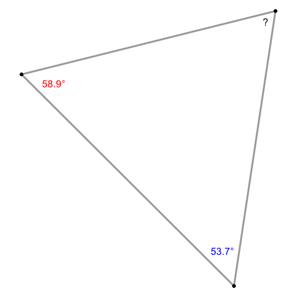

#### Question

5. A triangle is drawn. Two of the interior angle measures are known to be 35.3° and 71.2°. Find the third interior angle measure in degrees.

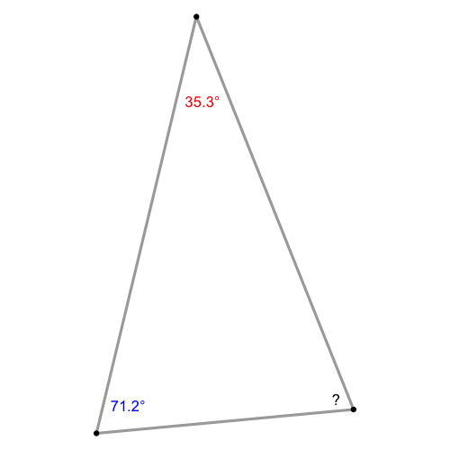

#### Question

6. A triangle is drawn. Two of the interior angle measures are known to be 42.5° and 100.3°. Find the third interior angle measure in degrees.

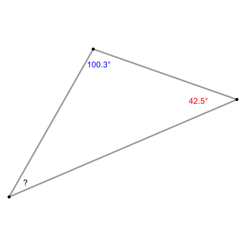

#### Question

7. A triangle is drawn. Two of the interior angle measures are known to be 45.6° and 46.1°. Find the third interior angle measure in degrees.

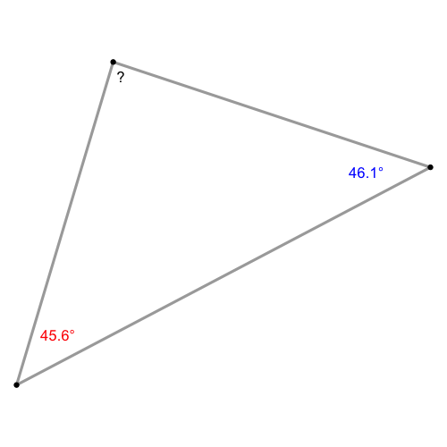

#### Question

8. A triangle is drawn. Two of the interior angle measures are known to be 41.3° and 97.1°. Find the third interior angle measure in degrees.

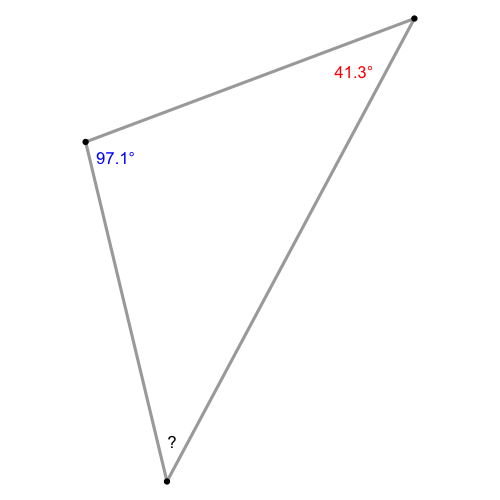